# Querying, Visualizing, and Running Inference on IMDb Database

Ali Salahi

### Preliminary

I found the database on GitHub under user ameerkat, in the repository imdb-to-sql. I chose to undertake take this project to learn and hone my SQL skills. I wanted to come up with moderately complex queries, so I progressively attempted to answer questions I found to be more and more ambitious. Generally, I aimed to complete a project, learn and grow comfortable with a new technology, and to work with data I found interesting; I’m glad I found a project that checked the three aforementioned boxes.

All of the code in this project is written in R with the ‘RSQLite’ package.

### How many actors are there in the database? How many movies?

```
library(RSQLite)
lean = dbConnect(drv = SQLite(), dbname = 'lean_imdbpy_2010_idx.db')
# Distinct person_id from cast_info2 because it maps to names2 which has 1 entry per actor
actor.count <- dbGetQuery( lean, 'SELECT COUNT( DISTINCT( person_id)) FROM cast_info2
                 WHERE role_id = 1 OR role_id = 2;')
# Don't distinct, raw count all titles that correlate as a movie
movie.count <- dbGetQuery( lean, 'SELECT COUNT( *) FROM title2
                 WHERE kind_id = 1;')
```

### What time period does the database cover?

The database covers the range of 2010, 2025, this was pulled from the title table which uniquely identifies every Tv series, or film, etc. I also checked the aka_title table to be safe, and found that it was a subset of our greater range. Further, the apparently extreme values (2025) are accurate, in that they reflect release dates, and production timelines for planned or in-production films.

```
#get range of movie years from title table
dbGetQuery( lean, 'SELECT MIN(production_year), MAX(production_year) FROM title2')
```

### What proportion of the actors are female? male?

The proportion of Male actors is 0.6663131, the proporton of female actors is complementarily 0.3336869. Although there are NA’s regarding gender in the database, none of them corresponded to the actors / actress role_id, I employed a sanity check to confirm this, and that the number of women and men added up to our previously acquired actor count, that I did not include in my abbreviated Code.

```
male <- dbGetQuery( lean, 'SELECT COUNT( DISTINCT( person_id))
                           FROM name2, cast_info2
                           WHERE name2.id = cast_info2.person_id
                               AND  gender = "m"
                               AND ( cast_info2.role_id = 1 OR cast_info2.role_id = 2);')
female <- actor.count - male
female <- female / actor.count
male <- male / actor.count
```

### What proportion of the entries in the movies table are actual movies and what proportion are television series, etc.?

The proportion of entries in the title table that are mapped to actual movies is 0.8100564, and the proportion mapped explicitly to TV Series is 0.1178782. I am aware that these computation could have been made explicitly in SQLite, I did find it troublesome and buggy, in that I could not get it to work (and I promise there’s some neat SQLite later).

```
kind.freq <- dbGetQuery( lean, 'SELECT kind_id, COUNT( *) FROM title2 GROUP BY kind_id')
kind.tot <- sum( kind.freq[, 2])
mov.freq <- kind.freq[1, 2] / kind.tot
tv.freq <- kind.freq[2, 2] / kind.tot
```

### How many genres are there? What are their names/descriptions?

There are 27 genres, and they are: “Horror”, “Drama”, “Comedy”, “Musical”, “Reality-TV”, “Talk-Show”, “Mystery”, “Music”, “News”, “Sport”, “Sci-Fi”, “Romance”, “Documentary”, “Family”, “Short”, “Biography”, “Crime”, “Fantasy”, “Animation”, “Game-Show”, “History”, “Action”, “Adventure”, “Thriller”, “War”, “Western”, “Adult”.

```
genre.inf <- dbGetQuery( lean, 'SELECT DISTINCT( info)
                                FROM movie_info2
                                WHERE info_type_id = 3;')
count.genre <- dim( genre.inf)[1]
```

### List the 10 most common genres of movies, showing the number of movies in each of these genres.

These Are:

```
##         Genres Frequency
## 1        Short    195478
## 2        Drama    120104
## 3       Comedy     69613
## 4  Documentary     58914
## 5     Thriller     28849
## 6       Horror     23004
## 7      Romance     21218
## 8       Action     18437
## 9       Family     17987
## 10     Fantasy     14764
```

```
top.gen <-
dbGetQuery( lean, 'SELECT DISTINCT( info) Genres, COUNT( *) Frequency
                   FROM movie_info2, title2
                   WHERE info_type_id = 3
                      AND movie_info2.movie_id = title2.id
                      AND (title2.kind_id = 1 OR title2.kind_id = 3 OR title2.kind_id = 4)
                   GROUP BY info
                   ORDER BY COUNT( *) DESC
                   LIMIT 10;')
```

### Find all movies with a given keyword, in this instance, ‘space’. How many are there? What are the years these were released? and who were the top 5 actors in each of these movies?

There were a couple roadbloacks I ran into on this problem, and they were all very lengthy, in their duration, to overcome. I found that some films did not have up to 5 top billed actors, one of them pops up in our readout. Further, I wanted to concatenate 5 columns of names per film to a table where each row is a movie. I could not configure this to my goal, but I was able to get up to 5 rows per film, the number of rows per film equating to the number of top billed actors. I have printed out the first twenty rows of this table:

```
##                              Name                            Title Year
## 1                    Cree, Steven                 51 Degrees North 2015
## 2                    Doyle, Jamie                 51 Degrees North 2015
## 3                   Nallon, Steve                 51 Degrees North 2015
## 4          von Zeddelmann, Moritz                 51 Degrees North 2015
## 5             Osterloh, Dolly-Ann                 51 Degrees North 2015
## 6              Antonopoulos, Erik                A House Undivided 2015
## 7                     Cox, Elliot                A House Undivided 2015
## 8                 Laipeneks, Matt                A House Undivided 2015
## 9                 McClure, Dawson                A House Undivided 2015
## 10              Zdrazil, Nicholas                A House Undivided 2015
## 11                   Kurnow, Alex                       Abduct Me! 2011
## 12                  Brown, Ariana                       Abduct Me! 2011
## 13              Mirenda, Angeline                       Abduct Me! 2011
## 14                     Burns, Tom               All Things Shining 2012
## 15                Napoli, Richard               All Things Shining 2012
## 16                    Osbeck, Jon               All Things Shining 2012
## 17 Sinclair, James Aaron Tecumseh               All Things Shining 2012
## 18              Kobza, Ashley Rae               All Things Shining 2012
## 19            Bashirov, Aleksandr Belka i Strelka. Zvezdnye sobaki 2010
## 20                Garmash, Sergey Belka i Strelka. Zvezdnye sobaki 2010
```

```
TopSpace <-
dbGetQuery( lean, 'SELECT DISTINCT(name2.name) Name, title Title, production_year Year
                   FROM movie_keyword2, keyword2, title2, cast_info2, name2
                   WHERE movie_keyword2.keyword_id = keyword2.id
                       AND movie_keyword2.movie_id = title2.id
                       AND movie_keyword2.movie_id = cast_info2.movie_id
                       AND cast_info2.person_id = name2.id
                        AND keyword2.keyword = "space"
                        AND nr_order BETWEEN 1 AND 5
                        AND (role_id = 1 OR role_id = 2)
                        AND (kind_id = 1 OR kind_id = 3 OR kind_id = 4)
                   LIMIT 20;')
```

### Has the number of movies in each genre changed over time? Plot the overall number of movies in each year over time, and for each genre.

The numbers certainly have changed, throughout time. I originally plotted these with the older database, but I have redirected my code to the newer database. I went with the handsome and expert advice of one of our TA’s and decided to tier the genres and plot them seperately, as lines.

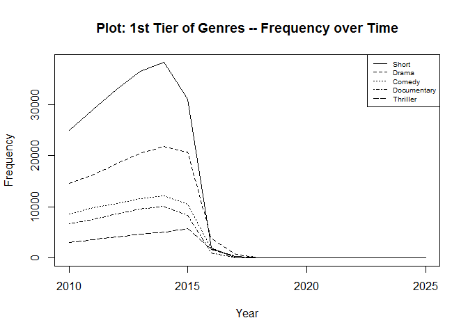

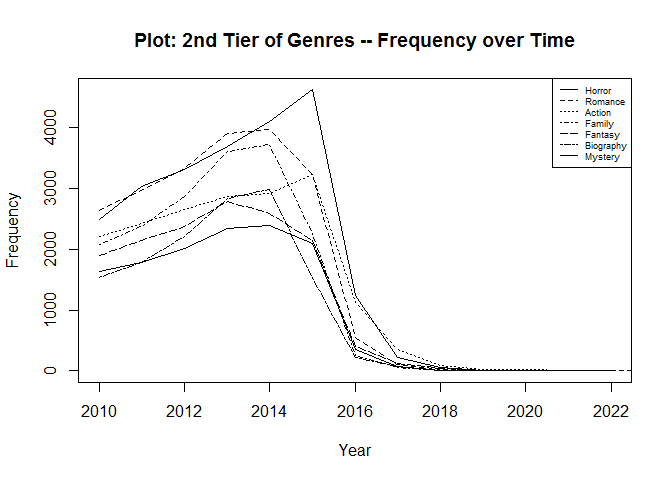

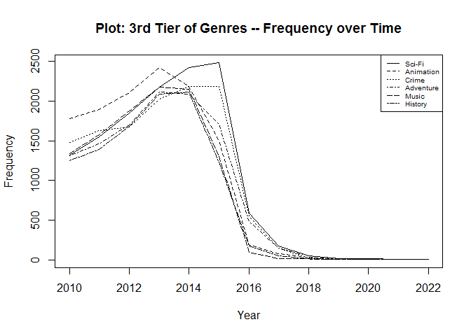

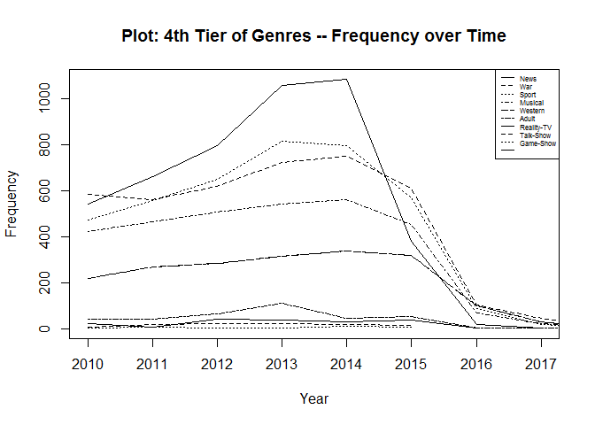

```
genre.year <- dbGetQuery( lean, 'SELECT title2.production_year, movie_info2.info, COUNT( *)
                                 FROM movie_info2, title2
                                 WHERE movie_info2.movie_id = title2.id
                                   AND info_type_id = 3
                                   AND title2.kind_id = 1
                                 GROUP BY title2.production_year, movie_info2.info;')

genre.year <- genre.year[ - which( is.na( genre.year[ ,1])), ]
genre.list <- unique( genre.year[, 2])
gy <- lapply(1:28, function(p){
  genre.year[ which( genre.year[, 2] == genre.list[ p]), c( 1, 3)]})
list.totals <- sapply(1:28, function(x) sum(gy[[x]][,2]))
ord.total <- order( list.totals)

plot1 <-
  plot( gy[[22]], type = "l", main = "Plot: 1st Tier of Genres -- Frequency over Time",
        xlab = "Year", ylab = "Frequency")
points( gy[[9]], type = "l", lty = 2)
points( gy[[6]], type = "l", lty = 3)
points( gy[[8]], type = "l", lty = 4)
points( gy[[25]], type = "l", lty = 5)
legend( x = "topright", legend = genre.list[ ord.total[ 28:24]], lty = 1:5, cex = .65)

plot2 <-
  plot( gy[[14]], type = "l", main = "Plot: 2nd Tier of Genres -- Frequency over Time",
        xlab = "Year", ylab = "Frequency")
points( gy[[20]], type = "l", lty = 2)
points( gy[[1]], type = "l", lty = 3)
points( gy[[10]], type = "l", lty = 4)
points( gy[[11]], type = "l", lty = 5)
points( gy[[5]], type = "l", lty = 6)
points( gy[[17]], type = "l", lty = 7)
legend( x = "topright", legend = genre.list[ ord.total[ 23:17]], lty = 1:7, cex = .575)

plot3 <-
  plot( gy[[21]], type = "l", main = "Plot: 3rd Tier of Genres -- Frequency over Time",
        xlab = "Year", ylab = "Frequency")
points( gy[[4]], type = "l", lty = 2)
points( gy[[7]], type = "l", lty = 3)
points( gy[[3]], type = "l", lty = 4)
points( gy[[15]], type = "l", lty = 5)
points( gy[[13]], type = "l", lty = 6)
legend( x = "topright", legend = genre.list[ ord.total[ 16:11]], lty = 1:6, cex = .6)

plot4 <-  plot( gy[[18]], type = "l", main = "Plot: 4th Tier of Genres -- Frequency over Time",
        xlab = "Year", ylab = "Frequency")
points( gy[[26]], type = "l", lty = 2)
points( gy[[23]], type = "l", lty = 3)
points( gy[[16]], type = "l", lty = 4)
points( gy[[27]], type = "l", lty = 5)
points( gy[[2]], type = "l", lty = 6)
points( gy[[19]], type = "l", lty = 7)
points( gy[[24]], type = "l", lty = 8)
points( gy[[12]], type = "l", lty = 9)
points( gy[[27]], type = "l", lty = 10)
legend( x = "topright", legend = genre.list[ ord.total[ 10:1]], lty = 1:10, cex = .475)
```

### Who are the actors that have been in the most movies? List the top 20.

The table is presented here:

```
##    person_id COUNT(*)                   name
## 1    1708783      200          Roberts, Eric
## 2    1025363      171         Kaufman, Lloyd
## 3     233482      151           Brahmanandam
## 4    1488023      150       O'Connor, George
## 5    1204854      148         Lorente, Txema
## 6    1705106      131          Rivers, Scott
## 7    3123037      131            Pell, Rhoda
## 8    2012005      120        Thingvall, Joel
## 9    1494693      116       Oberst Jr., Bill
## 10   3091849      116           Olsen, Maria
## 11    636012      115 Fischbach, Mark Edward
## 12    506474      111          Dewdney, Paul
## 13    760186      109       Graf, David Alan
## 14     60190      104       Andrisan, Rodrig
## 15   2046271      104           Trejo, Danny
## 16   1302470      103      Mazak, Kasey Ryne
## 17    831233      101   Harris, Lee Nicholas
## 18   1736974      100           Rosete, Jose
## 19   1494149       99          Obama, Barack
## 20   1549168       95            Pasha, Omer
```

```
top.act <-
dbGetQuery( lean, 'SELECT person_id, COUNT(*), name
            FROM  cast_info2, name2, title2
            WHERE role_id BETWEEN 1 AND 2
            AND cast_info2.person_id = name2.id
            AND cast_info2.movie_id = title2.id
            AND title2.kind_id = 1
            GROUP BY person_id ORDER BY COUNT(*) DESC LIMIT 20;')
```

### Who are the actors that have had the most number of movies with “top billing” (i.e., billed as 1, 2 or 3)? For each actor, also show the years these movies spanned?

An abbreviated table is presented:

```
##    person_id COUNT(*)                       name YearStart YearEnd
## 1    1204854      106             Lorente, Txema      2010    2015
## 2    1708783       75              Roberts, Eric      2010    2016
## 3    1881637       48              Sizemore, Tom      2010    2016
## 4    1488023       45           O'Connor, George      2014    2015
## 5    2046271       43               Trejo, Danny      2010    2015
## 6     292687       38 CalderÃ³n, Emilio Janhunen      2011    2015
## 7     257734       37             Brown, Shannon      2011    2016
## 8    1302470       37          Mazak, Kasey Ryne      2010    2015
## 9    1237239       35            Madsen, Michael      2010    2016
## 10   1381086       34                   Mohanlal      2010    2015
## 11   1651606       32               Raj, Prakash      2010    2015
## 12   1017191       30                 Karam, Joe      2012    2015
## 13   1462735       30          Nicholls, Matthew      2014    2015
## 14    421655       28            Cox, Timothy J.      2010    2016
## 15    662433       28              Franco, James      2010    2016
## 16   1668196       28                  Rea, Kyle      2010    2012
## 17   1104101       27              Kumar, Akshay      2010    2015
## 18   1494693       27           Oberst Jr., Bill      2010    2016
## 19   1140742       26              Lavant, Denis      2010    2016
## 20   1251951       25                  Mammootty      2010    2015
```

```
dbGetQuery( lean, 'SELECT person_id, COUNT(*), name, MIN(production_year), MAX(production_year)
            FROM  cast_info2, name2, title2
            WHERE role_id BETWEEN 1 AND 2
            AND cast_info2.person_id = name2.id
            AND cast_info2.movie_id = title2.id
            AND title2.kind_id = 1
            AND (nr_order = 1 OR nr_order = 2 OR nr_order = 3)
            GROUP BY person_id ORDER BY COUNT(*) DESC LIMIT 20;')
```

### Who are the 10 actors that have the most aliases (i.e., see the aka_names table).

The table is presented:

[output not shown]

```
dbGetQuery( lean, 'SELECT aka_name2.person_id, COUNT(*), name2.name
            FROM  cast_info2, name2, title2, aka_name2
            WHERE role_id BETWEEN 1 AND 2
            AND cast_info2.person_id = name2.id
            AND cast_info2.movie_id = title2.id
            AND aka_name2.person_id = name2.id
            AND title2.kind_id = 1
            GROUP BY aka_name2.person_id ORDER BY COUNT(*) DESC LIMIT 10;')
```

### What are the 10 television series that have the most number of movie stars appearing in the shows?

The table is presented (I realize my analysis have gone down in quality content, I hope it’s believable that this was a time issue, and not that of inability to talk about my code (I love talking about my code)):

```
##    Count                  title
## 1     35           A Band Apart
## 2     20         Gilley's Place
## 3     20              Sadda Haq
## 4     15           Grace Period
## 5     14      Kari Traa Leikane
## 6     14    Zhen ai hei bai pei
## 7     13               Yes, And
## 8     12           Life Stories
## 9     12             StartUpers
## 10    11            4 Ambientes
## 11    10        Awkward Moments
## 12    10 G.R.U.$.T.L.E. Diaries
## 13    10          Improv Nation
## 14     9             MasterChef
## 15     9       Nubbin & Friends
## 16     9          RDM: La Serie
## 17     9                Squeeze
## 18     9     The BFF Chronicles
## 19     9           ethanpaisley
## 20     8         Grean Possible
```

```
dbGetQuery( lean, 'SELECT COUNT( DISTINCT( person_id)) Count, title
            FROM  cast_info2, title2
            WHERE role_id BETWEEN 1 AND 2
            AND cast_info2.movie_id = title2.id
            AND title2.kind_id = 2
            AND (nr_order = 1 OR nr_order = 2 OR nr_order = 3)
            GROUP BY title ORDER BY Count DESC LIMIT 20;')
```